# Week 10 Quiz

Michael Alford

**Question 1**

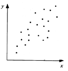

$0.671$

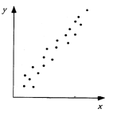

$0.986$

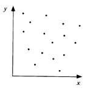

$0.008$

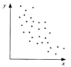

$-0.589$

**Question 2**

From the SPSS output below, what is the correlation value?

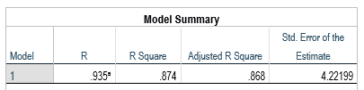

- $4.22199$
- $87.4%$
- $0.935$
- $0.874$
- $0.868$

**Question 3**

For the following data, use SPSS or other technology to calculate the correlation between the variables.

```r
knitr::kable(Q3, "pipe")
```

| x | y |
| --- | --- |
| 15 | 24 |
| 14 | 25 |
| 17 | 21 |
| 18 | 20 |
| 14 | 26 |
| 18 | 16 |
| 19 | 19 |
| 17 | 21 |
| 15 | 22 |
| 16 | 20 |

```r
round(cor(Q3$x, Q3$y), 3)
```

```
## [1] -0.867
```

- $-0.887$
- $-887$
- $-0.867$
- $-0.786$
- $0.87$

**Question 4**

Which of the following gives the correct linear regression equation?

- $\hat{height} = −39.619 + 4.983 \times tibia$
- $\hat{height} = 39.619−4.983 \times tibia$
- $\hat{tibia} = 4.983 \times height − 39.619$
- $\hat{height} = −39.619 + 20.203 \times tibia$
- $\hat{tibia} = 4.983 + 0.457 \times height$

**Question 5**

Wild bears were caught and anesthetised so that various measurements could be made. In particular, the usefulness of a bear’s chest circumference to predict its weight was of interest. A random sample of 10 bears was used, with the chest and weight measurements shown below, as well as the linear regression analysis.

```r
knitr::kable(Q5, "pipe")
```

| Chest | Weight |
| --- | --- |
| 26 | 80 |
| 45 | 344 |
| 54 | 416 |
| 49 | 348 |
| 35 | 166 |
| 41 | 220 |
| 41 | 262 |
| 49 | 360 |
| 38 | 204 |
| 31 | 144 |

```r
bearlm <- lm(Weight ~ Chest, data = Q5)
summary(bearlm)
```

```
##
## Call:
## lm(formula = Weight ~ Chest, data = Q5)
##
## Residuals:
##     Min      1Q  Median      3Q     Max
## -35.638 -12.543   2.370   9.139  38.841
##
## Coefficients:
##              Estimate Std. Error t value Pr(>|t|)
## (Intercept) -251.9479    33.8141  -7.451 7.26e-05 ***
## Chest         12.3801     0.8104  15.277 3.34e-07 ***
## ---
## Signif. codes:  0 '***' 0.001 '**' 0.01 '*' 0.05 '.' 0.1 ' ' 1
##
## Residual standard error: 21.18 on 8 degrees of freedom
## Multiple R-squared:  0.9669, Adjusted R-squared:  0.9627
## F-statistic: 233.4 on 1 and 8 DF,  p-value: 3.343e-07
```

What can be said about the y-intercept ($-251.948$) in the context of this study? (Select all that apply)

- The y-intercept would indicate the chest size of a bear with zero weight.
- The y-intercept is close to a number of the observed data values and therefore seems reliable.
- The y-intercept is meaningful in that it would represent the weight of bears when they are born.
- The y-intercept would indicate the weight of a bear with zero chest circumference.
- The y-intercept is based on extrapolation and therefore is not reliable.
- The y-intercept is not meaningful for this data as it would not make sense to have a bear with zero chest size or negative weight.

**Question 6**

Which option is the correct interpretation of the slope of the regression equation?

- An increase in tibia length of 1cm corresponds with an increase in height of 4.983cm.
- An increase in height of 1cm corresponds with an increase in tibia length of 4.983cm.
- An increase in tibia length of 1cm corresponds with an increase in height of 39.619cm.
- A decrease in tibia length of 39.619cm corresponds with an increase in height of 4.983cm.
- An increase in tibia length of 1cm corresponds with a decrease in height of 4.983cm.

**Question 7**

For the following data, use SPSS to calculate the regression equation to predict y from x, then select the correct answer.

```r
knitr::kable(Q7, "pipe")
```

| x | y |
| --- | --- |
| 15 | 20 |
| 14 | 19 |
| 17 | 23 |
| 18 | 24 |
| 14 | 17 |
| 18 | 24 |
| 19 | 26 |
| 17 | 22 |
| 15 | 18 |
| 16 | 20 |

```r
Q7lm <- lm(y ~ x, data = Q7)
summary(Q7lm)
```

```
##
## Call:
## lm(formula = y ~ x, data = Q7)
##
## Residuals:
##      Min       1Q   Median       3Q      Max
## -1.21352 -0.56228 -0.02847  0.52402  1.39146
##
## Coefficients:
##             Estimate Std. Error t value Pr(>|t|)
## (Intercept)  -4.8612     2.6127  -1.861   0.0998 .
## x             1.6050     0.1594  10.066 8.08e-06 ***
## ---
## Signif. codes:  0 '***' 0.001 '**' 0.01 '*' 0.05 '.' 0.1 ' ' 1
##
## Residual standard error: 0.8452 on 8 degrees of freedom
## Multiple R-squared:  0.9268, Adjusted R-squared:  0.9177
## F-statistic: 101.3 on 1 and 8 DF,  p-value: 8.082e-06
```

- $\hat{y} = −6.283 + 0.533x$
- $\hat{y} = −4.861 + 1.605x$
- $\hat{y} = 1.605 − 4.861x$
- $\hat{y} = 12.794 − 1.715x$
- $\hat{y} = 4 + 0.577x$

**Question 8**

Information on a number of flights from a particular airport was gathered, including the distance of the flight and how much it cost. Using this data, a scatterplot was generated along with a regression model.

```r
knitr::kable(Q8, "pipe")
```

| Distance | Cost |
| --- | --- |
| 568 | 219 |
| 933 | 222 |
| 720 | 249 |
| 1190 | 308 |
| 602 | 249 |
| 683 | 240 |
| 1719 | 252 |
| 589 | 229 |
| 327 | 183 |
| 894 | 209 |
| 419 | 199 |
| 749 | 248 |
| 749 | 301 |
| 392 | 238 |
| 657 | 205 |
| 461 | 232 |
| 1565 | 374 |
| 2150 | 343 |

```r
Q8lm <- lm(Cost ~ Distance, data = Q8)
summary(Q8lm)
```

```
##
## Call:
## lm(formula = Cost ~ Distance, data = Q8)
##
## Residuals:
##     Min      1Q  Median      3Q     Max
## -62.994 -25.164   0.854  16.305  70.574
##
## Coefficients:
##              Estimate Std. Error t value Pr(>|t|)
## (Intercept) 185.87405   16.81114  11.057 6.67e-09 ***
## Distance      0.07511    0.01713   4.384 0.000462 ***
## ---
## Signif. codes:  0 '***' 0.001 '**' 0.01 '*' 0.05 '.' 0.1 ' ' 1
##
## Residual standard error: 35.16 on 16 degrees of freedom
## Multiple R-squared:  0.5457, Adjusted R-squared:  0.5174
## F-statistic: 19.22 on 1 and 16 DF,  p-value: 0.000462
```

[figure not shown]

```r
plot(Q8$Distance ~ Q8$Cost, xlab = "Distance (km)", ylab = "Cost ($)")
abline(Q8lm)
```

Based on this, indicate your answers to the following questions.

1. The explanatory variable is
- Distance
- Cost
2. The response variable is
- Distance
- Cost
3. Based on the scatterplot, is the relationship:
- positive
- negative
4. Give the correlation of distance with cost. (give your answer to 3 decimal places, e.g. $0.453\ or\ -0.453$ if the relationship is negative)

```r
  round(cor(Q8$Distance, Q8$Cost), 3)
```

```
## [1] 0.739
```

5. What is the $R^2$ value? (give your answer as a percentage to 1 decimal place, e.g. 23.1, without the % sign)
- 54.6
6. The linear equation you would use to estimate the cost from distance is $\hat{y} = a + bx$ where:
- $a$ is 0.739 and $b$ is 0.564
- $a$ is 185.874 and $b$ is 16.811
- $a$ is 185.874 and $b$ is 0.075
- $a$ is 35.16288 and $b$ is 185.874
7. Use the equation to predict the cost of a flight that is 800km. (give your answer to 2 decimal places without the $ sign)

$$\begin{aligned}
\hat{y} &= a + bx\\
&= 185.874 + 0.075 \times 800\\
&= 245.87
\end{aligned}$$

8. Is this answer:
- reliable because it is not based on extrapolation or
- unreliable because it is based on extrapolation?

**Question 9**

Is the relationship between tibia length and height significant using $\alpha = 0.01$? Select the correct option.

- $t = 11.198\ and\ P = 0.000$ so the relationship is significant
- $t = 11.198\ and\ P = 0.000$ so the relationship is not significant
- $t = 11.198\ and\ P = 0.024$ so the relationship is not significant
- $t = -2.461\ and\ P = 0.024$ so the relationship is not significant
- $t = -2.461\ and\ P = 0.012$ so the relationship is significant

**Question 10**

For the following data, use SPSS to obtain the regression output to predict y from x.

```r
knitr::kable(Q10, "pipe")
```

| x | y |
| --- | --- |
| 15 | 20 |
| 14 | 19 |
| 17 | 23 |
| 18 | 24 |
| 14 | 17 |
| 18 | 24 |
| 19 | 26 |
| 17 | 22 |
| 15 | 18 |
| 16 | 20 |

```r
Q10lm <- lm(y ~ x, data = Q10)
summary(Q10lm)
```

```
##
## Call:
## lm(formula = y ~ x, data = Q10)
##
## Residuals:
##      Min       1Q   Median       3Q      Max
## -1.21352 -0.56228 -0.02847  0.52402  1.39146
##
## Coefficients:
##             Estimate Std. Error t value Pr(>|t|)
## (Intercept)  -4.8612     2.6127  -1.861   0.0998 .
## x             1.6050     0.1594  10.066 8.08e-06 ***
## ---
## Signif. codes:  0 '***' 0.001 '**' 0.01 '*' 0.05 '.' 0.1 ' ' 1
##
## Residual standard error: 0.8452 on 8 degrees of freedom
## Multiple R-squared:  0.9268, Adjusted R-squared:  0.9177
## F-statistic: 101.3 on 1 and 8 DF,  p-value: 8.082e-06
```

Is there a significant relationship between the variables at $\alpha = 0.05$? From your output, select the test statistic value and P for this hypothesis test.

- $t = 3.246\ and\ P = 0.012$ (significant relationship)
- $t = -1.861\ and\ P = 0.100$ (no significant relationship)
- $t = 10.066\ and\ P = 0.100$ (no significant relationship)
- $t = 10.066\ and\ P = 0.05$ (no significant relationship)
- $t = 10.066\ and\ P < 0.001$ (significant relationship)